# tips

# Suggestions and FAQs

(I’ll be adding stuff to this section as I encounter it)

## When do I need to use weights?

You’ll typically use a weighting variable when you’re working with survey data. In this course, the `nes` data set will include a weight variable (`wt`), but there aren’t any weights for the `world` or `states` data sets.

Weighting is used to make samples more closely resemble a target population. For instance, the NES has slightly more women respondents than you would expect from a true random sample from the general population so including the weighting variable makes the responses from men count more and the responses from women count slightly less.

| gender | unweighted | weighted |
| --- | --- | --- |
| 1. Male | 3763 (46%) | 3964 (48%) |
| 2. Female | 4450 (54%) | 4262 (52%) |

This concern isn’t really relevant for the `world` and `states` data sets because these aren’t samples: the states data set has data on the entire population of U.S. states, and the world data set has data on (more or less) all the countries.

## Do I need to use `svyglm()`?

They `svyglm` function is used to run a weighted regression, but the final project data doesn’t have any weights associated with it, so you don’t need any of the `svy` commands to do your analysis. Keep in mind, however, that these data are still not representative of the general population, so you should acknowledge that this is a non-random sample when you discuss your results.

## Is it okay if my results are not significant?

**You are not obligated to find statistically significant results. As long as you make a reasonable argument for why your hypothesis is worth testing, this is completely fine.** If you do find that your hypothesis isn’t supported, you still need to interpret the coefficients, plot the results etc. you just need to say that you’ve failed to reject the null. In the concluding section of the paper, you would also want to talk about why you think your hypothesis wasn’t supported. A few plausible reasons are: you’re wrong, there’s not enough data, there’s uncontrolled confounding, or the sample is biased. You don’t need to give a definitive explanation, just show you’re thinking about your results and that you [understand what it means to reject or not reject the null hypothesis](https://amstat.tandfonline.com/doi/full/10.1080/00031305.2016.1154108#:~:text=the%20statistical%20community.-,2.%20What%20is%20a%20p%2DValue%3F,-Informally%2C%20a%20p).

(If you think there’s uncontrolled confounding and it comes from a variable that already exists in the data, you might as well test it! But its entirely possible that there’s some other confounding variable that wasn’t included in the data, in which case its fine to say “I suspect this matters, but I can’t test it”)

## How can I make sure that my code is replicable?

Before submitting your R-code, its a good idea to double-check and make sure everything runs properly. The best way to do this is: restart R, press little broom icon in the environment pane to make sure you’ve cleared all of the your data out, and then run your script one line at a time and make sure that you don’t see any errors. If you’re not able to reproduce the results in your paper, then you may need to check to make sure you have everything in the right order.

## What does the `$` symbol mean (as in`world$ccode`)

The `$` notation is one way that we can access a specific column of a dataframe in R. For instance, here’s a portion of the `states` data set:

| state | attend.pct | abortlaws |
| --- | --- | --- |
| Alabama | 52 | 8 |
| Alaska | 22 | 8 |
| Arizona | 29 | 11 |
| Arkansas | 50 | 10 |
| California | 33 | 5 |

If I want to access the `attend.pct` variable, I can just type:

```r
states$attend.pct
```

Typing out a data set name and a dollar sign can get a little tedious, so many R functions will allow you to use an optional `data` argument that will allow you to be a little more concise. So these two commands will generate the exact same result, the only difference is that adding `data=states` saves me from having to write `states$...` over and over:

```
===========================================================================
                         Mean Comparison Analysis
===========================================================================


Table: Mean Values of attend.pct by region

              Mean    N   St. Dev.
----------  ------  ---  ---------
Northeast    29.56    9       5.77
Midwest      40.83   12       4.39
South        46.88   16       7.16
West         33.92   13       8.59
Total        38.94   50       9.37
```

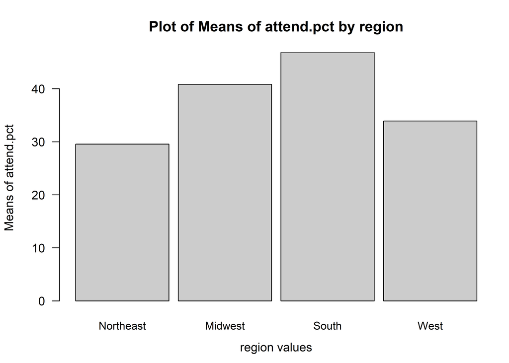

```r
# with the data = argument
compmeansC(dv = attend.pct, iv = region, data=states)
```

```
===========================================================================
                         Mean Comparison Analysis
===========================================================================


Table: Mean Values of states$attend.pct by states$region

              Mean    N   St. Dev.
----------  ------  ---  ---------
Northeast    29.56    9       5.77
Midwest      40.83   12       4.39
South        46.88   16       7.16
West         33.92   13       8.59
Total        38.94   50       9.37
```

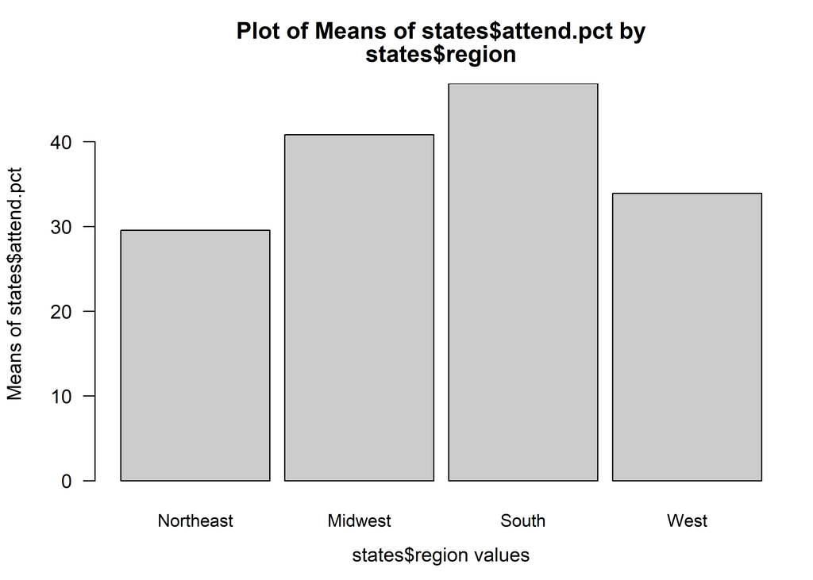

```r
# without the data = argument
compmeansC(dv= states$attend.pct, iv = states$region)
```

## What does `na.rm=T` mean?

`na.rm=T` is an optional command that will allow us to calculate summary statistics for data that has missing values. When an observation has some missing values, R will use a special `NA` value as a placeholder for that cell. This is a problem when we want to calculate a summary statistic because `NA` doesn’t have any mathematical meaning: its just non-existent data.

By default, taking the `mean`, `median`, `sum` etc. from a vector with any `NA` values will just return `NA`:

```r
mean(world$gdp.growth)
```

```
[1] NA
```

So, adding `na.rm=T` will just tell R to ignore any `NA` values and perform the calculation only on the valid observations:

```r
mean(world$gdp.growth, na.rm=T)
```

```
[1] 2.982785
```